# Ames Housing Model Analysis, Part 1

Steven Slezak

31 March 2018

# 1 Initial Preparation of the Data Sets

Our analysis of 10 different ML methods applied to the *Ames* housing data is divided into two parts. The first section deals with developing the benchmark model, multilinear regression. It also includes first efforts at feature selection and feature importance. [The second part](https://seslezak.github.io/Ames_Housing_Study/Ames_Models_Pt02.html) of the analysis examines other model methods and different approaches to feature selection.

The two parts structure the *Ames* data differently. To start, we are trying to develop a base model for submission to Kaggle. This requires working with the *train.csv* and *test.csv* files from Kaggle’s [*House Prices: Advanced Regression Techniques*](https://www.kaggle.com/c/house-prices-advanced-regression-techniques) competition.

To start, we need to load the required libraries.

```r
library(tidyverse)
library(ggplot2)
library(rapportools)
library(ragtop)
library(corrplot)
library(usdm)
library(fastDummies)
library(broom)
library(car)
library(leaps)
library(glmnet)
library(pls)
library(tree)
library(randomForest)
library(gbm)
library(e1071)
library(Matrix)
```

Next, download the *train.csv* and *test.csv* files for the Kaggle competition.

```r
AmesTrURL <- 'https://raw.githubusercontent.com/seslezak/Ames_Housing_Models/master/data/train.csv'
AmesTr <- read.csv(url(AmesTrURL), sep = ",", header = TRUE, stringsAsFactors = FALSE,
                   na.strings = c('', 'NA'))
AmesTstURL <- 'https://raw.githubusercontent.com/seslezak/Ames_Housing_Models/master/data/test.csv'
AmesTst <- read.csv(url(AmesTstURL), sep = ",", header = TRUE, stringsAsFactors = FALSE,
                   na.strings = c('', 'NA'))
```

As with the previous *Ames* EDA exercise, much data preparation needs to be done. Most of the data cleaning involves replacing *NA* strings with proper values and changing other character strings to factors or numerics. We also need to trim the size of the data frames so they are consistent. The following code was explained in the EDA problem statement, so we will just run them here without further mention.

We are performing this preparation on a data set consisting of the combined *CSV* files. We will split the combined file later into training and test sets, so both halves will be have been cleaned and prepped the same way.

The last step in this chunk creates a filtered list of numeric features in the *Ames* data. We will suppress the results because they are lengthy and were already explored in the first *Ames* problem statement.

```r
SalePrice <- AmesTr[, c('SalePrice')]
SalePrice <- SalePrice[-1460]
AmesTr <- AmesTr[-1460, ]
AmesTr <- rbind(AmesTr[, -81], AmesTst)
head(AmesTr)
dim(AmesTr)
str(AmesTr)
str(Filter(is.numeric, AmesTr))
AmesTr$Id <- NULL
AmesTst$Id <- NULL
dim(AmesTr)
pryr::object_size(AmesTr)
anyDuplicated(AmesTr)
summary(AmesTr)
str(AmesTr)

AmesTr$MSSubClass <- as.factor(AmesTr$MSSubClass)
AmesTr$OverallQual <- as.factor(AmesTr$OverallQual)
AmesTr$OverallCond <- as.factor(AmesTr$OverallCond)
AmesTr$BsmtFullBath <- as.factor(AmesTr$BsmtFullBath)
AmesTr$BsmtHalfBath <- as.factor(AmesTr$BsmtHalfBath)
AmesTr$FullBath <- as.factor(AmesTr$FullBath)
AmesTr$HalfBath <- as.factor(AmesTr$HalfBath)
AmesTr$BedroomAbvGr <- as.factor(AmesTr$BedroomAbvGr)
AmesTr$KitchenAbvGr <- as.factor(AmesTr$KitchenAbvGr)
AmesTr$TotRmsAbvGrd <- as.factor(AmesTr$TotRmsAbvGrd)
AmesTr$Fireplaces <- as.factor(AmesTr$Fireplaces)
AmesTr$GarageCars <- as.factor(AmesTr$GarageCars)
AmesTr$MoSold <- as.factor(AmesTr$MoSold)

sum(is.na(AmesTr))
sum(is.empty(AmesTr))
nan_sums <- colSums(is.na(AmesTr))
nan_sums[nan_sums > 0]
match(c('Alley', 'PoolArea', 'PoolQC', 'Fence', 'MiscFeature'), names(AmesTr))

AmesTr <- AmesTr[, -c(6, 71:74)]
dim(AmesTr)

medianLotFrontage <- median(AmesTr$LotFrontage, na.rm = TRUE)
medianMasVnrArea <- median(AmesTr$MasVnrArea, na.rm = TRUE)
medianBsmtFinSF1 <- median(AmesTr$BsmtFinSF1, na.rm = TRUE)
medianBsmtFinSF2 <- median(AmesTr$BsmtFinSF2, na.rm = TRUE)
medianBsmtUnfSF <- median(AmesTr$BsmtUnfSF, na.rm = TRUE)
medianTotalBsmtSF <- median(AmesTr$TotalBsmtSF, na.rm = TRUE)
medianGarageYrBlt <- median(AmesTr$GarageYrBlt, na.rm = TRUE)
medianGarageArea <- median(AmesTr$GarageArea, na.rm = TRUE)

AmesTr$LotFrontage[is.na(AmesTr$LotFrontage)] <- medianLotFrontage
AmesTr$MasVnrArea[is.na(AmesTr$MasVnrArea)] <- medianMasVnrArea
AmesTr$BsmtFinSF1[is.na(AmesTr$BsmtFinSF1)] <- medianBsmtFinSF1
AmesTr$BsmtFinSF2[is.na(AmesTr$BsmtFinSF2)] <- medianBsmtFinSF2
AmesTr$BsmtUnfSF[is.na(AmesTr$BsmtUnfSF)] <- medianBsmtUnfSF
AmesTr$TotalBsmtSF[is.na(AmesTr$TotalBsmtSF)] <- medianTotalBsmtSF
AmesTr$GarageYrBlt[is.na(AmesTr$GarageYrBlt)] <- medianGarageYrBlt
AmesTr$GarageArea[is.na(AmesTr$GarageArea)] <- medianGarageArea
nan_sums <- colSums(is.na(AmesTr))
nan_sums[nan_sums > 0]
sum(is.empty(AmesTr))

AmesTr$BsmtFullBath <- as.character(AmesTr$BsmtFullBath)
AmesTr$BsmtHalfBath <- as.character(AmesTr$BsmtHalfBath)
AmesTr$GarageCars <- as.character(AmesTr$GarageCars)

AmesTr$BsmtQual[is.na(AmesTr$BsmtQual)] <- 'w/o'
AmesTr$BsmtCond[is.na(AmesTr$BsmtCond)] <- 'w/o'
AmesTr$BsmtExposure[is.na(AmesTr$BsmtExposure)] <- 'w/o'
AmesTr$BsmtFinType1[is.na(AmesTr$BsmtFinType1)] <- 'w/o'
AmesTr$BsmtFinType2[is.na(AmesTr$BsmtFinType2)] <- 'w/o'
AmesTr$BsmtFullBath[is.na(AmesTr$BsmtFullBath)] <- 'w/o'
AmesTr$BsmtHalfBath[is.na(AmesTr$BsmtHalfBath)] <- 'w/o'
AmesTr$FireplaceQu[is.na(AmesTr$FireplaceQu)] <- 'w/o'
AmesTr$GarageType[is.na(AmesTr$GarageType)] <- 'w/o'
AmesTr$GarageFinish[is.na(AmesTr$GarageFinish)] <- 'w/o'
AmesTr$GarageCars[is.na(AmesTr$GarageCars)] <- 'w/o'
AmesTr$GarageQual[is.na(AmesTr$GarageQual)] <- 'w/o'
AmesTr$GarageCond[is.na(AmesTr$GarageCond)] <- 'w/o'

AmesTr <- as.data.frame(unclass(AmesTr))
str(AmesTr)
sum(is.empty(AmesTr))
nan_sums[nan_sums > 0]

AmesTr$MasVnrType[is.na(AmesTr$MasVnrType)] <- 'None'
AmesTr$Electrical[is.na(AmesTr$Electrical)] <- 'SBrkr'
AmesTr$MSZoning[is.na(AmesTr$MSZoning)] <- 'RL'
AmesTr$Utilities[is.na(AmesTr$Utilities)] <- 'AllPub'
AmesTr$Exterior1st[is.na(AmesTr$Exterior1st)] <- 'VinylSd'
AmesTr$Exterior2nd[is.na(AmesTr$Exterior2nd)] <- 'VinylSd'
AmesTr$KitchenQual[is.na(AmesTr$KitchenQual)] <- 'TA'
AmesTr$Functional[is.na(AmesTr$Functional)] <- 'Typ'
AmesTr$SaleType[is.na(AmesTr$SaleType)] <- 'WD'

nan_sums <- colSums(is.na(AmesTr))
nan_sums[nan_sums > 0]
sum(is.empty(AmesTr$Electrical))
sum(is.empty(AmesTr$MasVnrType))
sum(is.empty(AmesTr))
str(Filter(is.numeric, AmesTr))
```

# 2 Checking for Collinearity

We need to look for correlations between the numeric values to check for redundancy. We will perform a Variance Inflation Factor (VIF) analysis to identify any multicollinearity in the data.

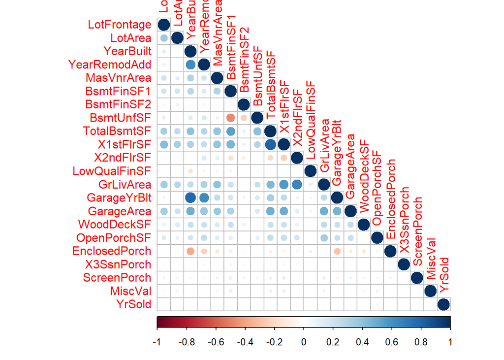

```r
CorTable <- cor(Filter(is.numeric, AmesTr))
corrplot::corrplot(CorTable, type = 'lower')
```

```r
numerics <- Filter(is.numeric, AmesTr)
usdm::vif(numerics)
```

```
##        Variables       VIF
## 1    LotFrontage     1.365
## 2        LotArea     1.258
## 3      YearBuilt     3.406
## 4   YearRemodAdd     1.873
## 5     MasVnrArea     1.364
## 6     BsmtFinSF1 25624.686
## 7     BsmtFinSF2  3532.797
## 8      BsmtUnfSF 23847.019
## 9    TotalBsmtSF 23977.922
## 10     X1stFlrSF       Inf
## 11     X2ndFlrSF       Inf
## 12  LowQualFinSF       Inf
## 13     GrLivArea       Inf
## 14   GarageYrBlt     3.073
## 15    GarageArea     1.842
## 16    WoodDeckSF     1.190
## 17   OpenPorchSF     1.193
## 18 EnclosedPorch     1.209
## 19    X3SsnPorch     1.010
## 20   ScreenPorch     1.056
## 21       MiscVal     1.025
## 22        YrSold     1.008
```

The high values associated with Basement features indicate collinearity exists there, so we need to make sure not to include more than one Basement feature in the model. In addition, features related to the square footage of living space are showing *Infinite* VIF scores, which means the data may have some problems associated with high dimensionality. We will discuss this more in a bit.

Next, convert the data frame to the *tibble* format for subequent steps in the analysis, beginning with the preparation of dummy variables.

```r
AmesTrTib <- as_tibble(AmesTr)
AmesTrTib
```

```
## # A tibble: 2,918 x 74
##    MSSubClass MSZoning LotFrontage LotArea Street LotShape LandContour
##    <fct>      <fct>          <dbl>   <int> <fct>  <fct>    <fct>
##  1 60         RL               65.    8450 Pave   Reg      Lvl
##  2 20         RL               80.    9600 Pave   Reg      Lvl
##  3 60         RL               68.   11250 Pave   IR1      Lvl
##  4 70         RL               60.    9550 Pave   IR1      Lvl
##  5 60         RL               84.   14260 Pave   IR1      Lvl
##  6 50         RL               85.   14115 Pave   IR1      Lvl
##  7 20         RL               75.   10084 Pave   Reg      Lvl
##  8 60         RL               68.   10382 Pave   IR1      Lvl
##  9 50         RM               51.    6120 Pave   Reg      Lvl
## 10 190        RL               50.    7420 Pave   Reg      Lvl
## # ... with 2,908 more rows, and 67 more variables: Utilities <fct>,
## #   LotConfig <fct>, LandSlope <fct>, Neighborhood <fct>,
## #   Condition1 <fct>, Condition2 <fct>, BldgType <fct>, HouseStyle <fct>,
## #   OverallQual <fct>, OverallCond <fct>, YearBuilt <int>,
## #   YearRemodAdd <int>, RoofStyle <fct>, RoofMatl <fct>,
## #   Exterior1st <fct>, Exterior2nd <fct>, MasVnrType <fct>,
## #   MasVnrArea <int>, ExterQual <fct>, ExterCond <fct>, Foundation <fct>,
## #   BsmtQual <fct>, BsmtCond <fct>, BsmtExposure <fct>,
## #   BsmtFinType1 <fct>, BsmtFinSF1 <int>, BsmtFinType2 <fct>,
## #   BsmtFinSF2 <int>, BsmtUnfSF <int>, TotalBsmtSF <int>, Heating <fct>,
## #   HeatingQC <fct>, CentralAir <fct>, Electrical <fct>, X1stFlrSF <int>,
## #   X2ndFlrSF <int>, LowQualFinSF <int>, GrLivArea <int>,
## #   BsmtFullBath <fct>, BsmtHalfBath <fct>, FullBath <fct>,
## #   HalfBath <fct>, BedroomAbvGr <fct>, KitchenAbvGr <fct>,
## #   KitchenQual <fct>, TotRmsAbvGrd <fct>, Functional <fct>,
## #   Fireplaces <fct>, FireplaceQu <fct>, GarageType <fct>,
## #   GarageYrBlt <int>, GarageFinish <fct>, GarageCars <fct>,
## #   GarageArea <int>, GarageQual <fct>, GarageCond <fct>,
## #   PavedDrive <fct>, WoodDeckSF <int>, OpenPorchSF <int>,
## #   EnclosedPorch <int>, X3SsnPorch <int>, ScreenPorch <int>,
## #   MiscVal <int>, MoSold <fct>, YrSold <int>, SaleType <fct>,
## #   SaleCondition <fct>
```

```r
AmesTrDummy <- dummy_cols(AmesTrTib, remove_first_dummy = TRUE)
str(AmesTrDummy)
```

```
## Classes 'tbl_df', 'tbl' and 'data.frame':    2918 obs. of  373 variables:
##  $ MSSubClass           : Factor w/ 16 levels "20","30","40",..: 6 1 6 7 6 5 1 6 5 16 ...
##  $ MSZoning             : Factor w/ 5 levels "C (all)","FV",..: 4 4 4 4 4 4 4 4 5 4 ...
##  $ LotFrontage          : num  65 80 68 60 84 85 75 68 51 50 ...
##  $ LotArea              : int  8450 9600 11250 9550 14260 14115 10084 10382 6120 7420 ...
##  $ Street               : Factor w/ 2 levels "Grvl","Pave": 2 2 2 2 2 2 2 2 2 2 ...
##  $ LotShape             : Factor w/ 4 levels "IR1","IR2","IR3",..: 4 4 1 1 1 1 4 1 4 4 ...
##  $ LandContour          : Factor w/ 4 levels "Bnk","HLS","Low",..: 4 4 4 4 4 4 4 4 4 4 ...
##  $ Utilities            : Factor w/ 2 levels "AllPub","NoSeWa": 1 1 1 1 1 1 1 1 1 1 ...
##  $ LotConfig            : Factor w/ 5 levels "Corner","CulDSac",..: 5 3 5 1 3 5 5 1 5 1 ...
##  $ LandSlope            : Factor w/ 3 levels "Gtl","Mod","Sev": 1 1 1 1 1 1 1 1 1 1 ...
##  $ Neighborhood         : Factor w/ 25 levels "Blmngtn","Blueste",..: 6 25 6 7 14 12 21 17 18 4 ...
##  $ Condition1           : Factor w/ 9 levels "Artery","Feedr",..: 3 2 3 3 3 3 3 5 1 1 ...
##  $ Condition2           : Factor w/ 8 levels "Artery","Feedr",..: 3 3 3 3 3 3 3 3 3 1 ...
##  $ BldgType             : Factor w/ 5 levels "1Fam","2fmCon",..: 1 1 1 1 1 1 1 1 1 2 ...
```

[output cut: 87 more lines]

# 3 Creating Dummy Variables and Normalizing

Because many features will be converted to dummies, we need to remove the original features from the data set.

```r
names(Filter(is.factor, AmesTrDummy))
```

```
##  [1] "MSSubClass"    "MSZoning"      "Street"        "LotShape"
##  [5] "LandContour"   "Utilities"     "LotConfig"     "LandSlope"
##  [9] "Neighborhood"  "Condition1"    "Condition2"    "BldgType"
## [13] "HouseStyle"    "OverallQual"   "OverallCond"   "RoofStyle"
## [17] "RoofMatl"      "Exterior1st"   "Exterior2nd"   "MasVnrType"
## [21] "ExterQual"     "ExterCond"     "Foundation"    "BsmtQual"
## [25] "BsmtCond"      "BsmtExposure"  "BsmtFinType1"  "BsmtFinType2"
## [29] "Heating"       "HeatingQC"     "CentralAir"    "Electrical"
## [33] "BsmtFullBath"  "BsmtHalfBath"  "FullBath"      "HalfBath"
## [37] "BedroomAbvGr"  "KitchenAbvGr"  "KitchenQual"   "TotRmsAbvGrd"
## [41] "Functional"    "Fireplaces"    "FireplaceQu"   "GarageType"
## [45] "GarageFinish"  "GarageCars"    "GarageQual"    "GarageCond"
## [49] "PavedDrive"    "MoSold"        "SaleType"      "SaleCondition"
```

```r
dropCols <- c("MSSubClass", "MSZoning", "Street", "LotShape", "LandContour",
              "Utilities", "LotConfig", "LandSlope", "Neighborhood", "Condition1",
              "Condition2", "BldgType", "HouseStyle", "OverallQual", "OverallCond",
              "RoofStyle", "RoofMatl", "Exterior1st", "Exterior2nd", "MasVnrType",
              "ExterQual", "ExterCond", "Foundation", "BsmtQual", "BsmtCond",
              "BsmtExposure", "BsmtFinType1", "BsmtFinType2", "Heating", "HeatingQC",
              "CentralAir", "Electrical", "BsmtFullBath", "BsmtHalfBath", "FullBath",
              "HalfBath", "BedroomAbvGr", "KitchenAbvGr", "KitchenQual", "TotRmsAbvGrd",
              "Functional", "Fireplaces", "FireplaceQu", "GarageType", "GarageFinish",
              "GarageCars", "GarageQual", "GarageCond", "PavedDrive","MoSold",
              "SaleType", "SaleCondition")
AmesTrDummy <- AmesTrDummy %>% dplyr::select(-one_of(dropCols))
```

A quick sanity check to make sure the data looks they way we expect them to.

```r
dim(AmesTrDummy)
```

```
## [1] 2918  321
```

```r
nan_sums <- colSums(is.na(AmesTrDummy))
nan_sums[nan_sums > 0]
```

```
## named numeric(0)
```

```r
sum(is.empty(AmesTrDummy))
```

```
## [1] 840687
```

The next step is to scale or normalize features.

```r
AmesTrDummy <- scale(AmesTrDummy, center = TRUE, scale = TRUE)
AmesTrDumScaleDF <- as.tibble(AmesTrDummy)
```

The final step in data preparation is getting data ready to analyze and model. Start by splitting the combined file back into training and test files. Their structures are similar because we did data prep on the combined file.

The Kaggle competition requires a particular format for submission so we create a data column *id*, numbered from 1461, to satisfy competition rules.

```r
AmesTrain <- AmesTrDumScaleDF[1:1459, ]
AmesTrain <- cbind(AmesTrain, SalePrice)
AmesTest <- AmesTrDumScaleDF[1460:2918, ]
id <- 1461:2919
```

# 4 Preparing the Benchmark Model

The benchmark for this study is multilinear regression, which we will use to set a baseline for the *RMSE* metric. We will also use regression to help determine which features in the data are most useful for modeling and predictive purposes. The code chunk below identifies the top 25 features in importance.

Keep in mind this result comes from a regression technique. Other regression techniques will generally identify them same features as important, but they may order them differently. The differences are not significant and do not seem to impact the predictive capacity of the models. We will see later that other methods yield different features and order them differently in importance.

```r
lmRating <- lm(SalePrice ~ . , AmesTrain)
lmCoefs <- tidy(lmRating)
lmCoefs$abs_est <- sqrt(lmCoefs$estimate^2)
lmCoefsAbs <- lmCoefs[-c(2:5)]
lmCoefsAbs <- lmCoefsAbs[-1,]
head(lmCoefsAbs[order(-lmCoefsAbs$abs_est), ], 25)
```

```
##                     term abs_est
## 11             X2ndFlrSF   25541
## 10             X1stFlrSF   19739
## 7             BsmtFinSF1   16592
## 131     RoofMatl_ClyTile   12585
## 4              YearBuilt   11449
## 89       Condition2_PosN    9753
## 108       OverallQual_10    8933
## 106        OverallQual_9    8481
## 287         SaleType_New    7137
## 9              BsmtUnfSF    7075
## 71  Neighborhood_StoneBr    5270
## 3                LotArea    5204
## 63  Neighborhood_NridgHt    5047
## 8             BsmtFinSF2    4893
## 177       `BsmtQual_w/o`    4472
## 104        OverallQual_8    4425
## 14            GarageArea    4311
## 114        OverallCond_7    4215
## 96     HouseStyle_1Story    4175
## 55  Neighborhood_Crawfor    4113
## 105        OverallQual_5    4108
## 231       KitchenQual_Ex    4049
## 56  Neighborhood_NoRidge    4032
## 249         Fireplaces_2    4003
## 248         Fireplaces_1    3862
```

Let’s pick a few numeric features and plot them to see if there are any linear relationships between them and the target, the *SalePrice* for each house. It appears linear relations exist.

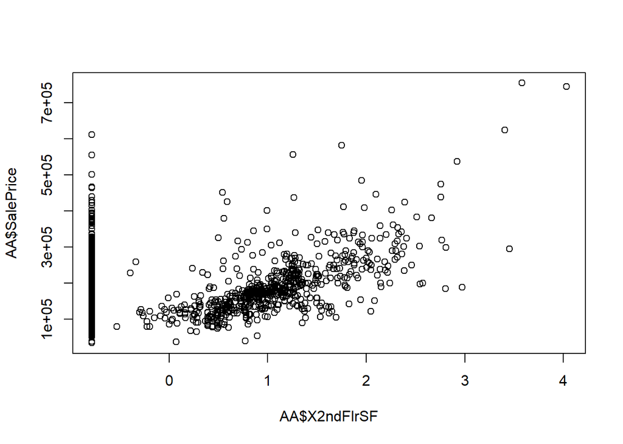

```r
AA <- AmesTrain
plot(AA$X2ndFlrSF, AA$SalePrice)
```

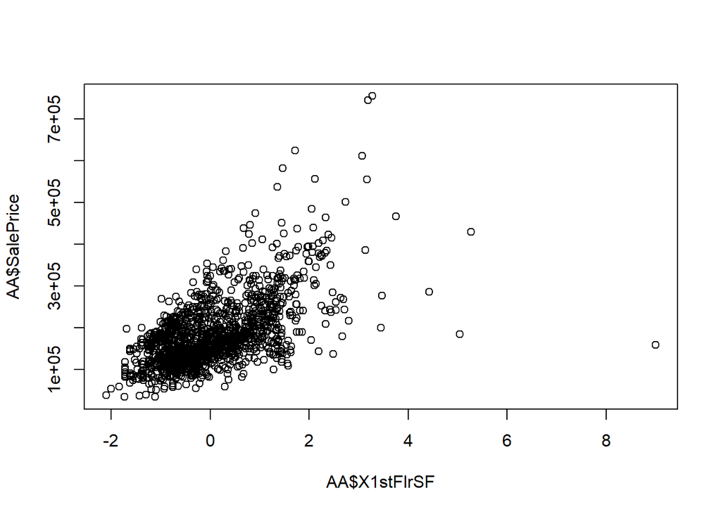

```r
plot(AA$X1stFlrSF, AA$SalePrice)
```

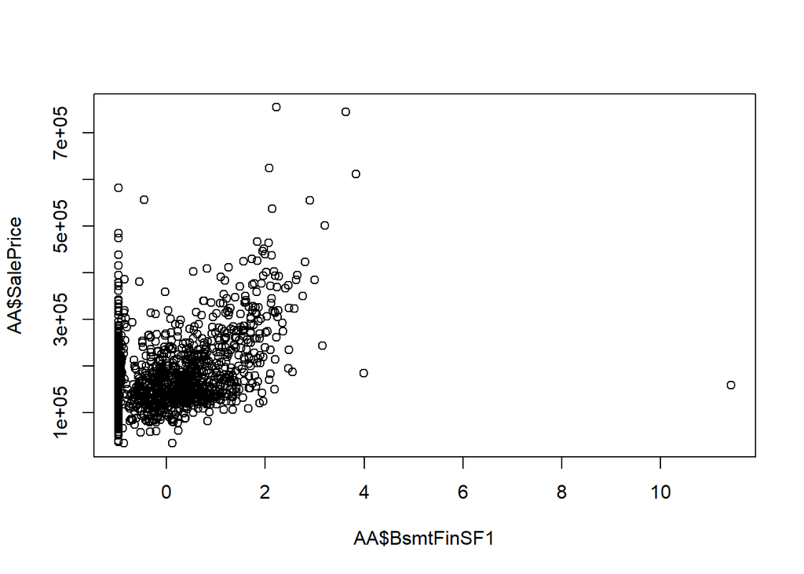

```r
plot(AA$BsmtFinSF1, AA$SalePrice)
```

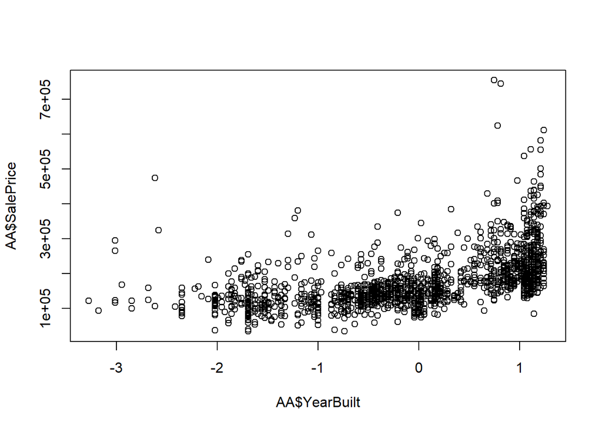

```r
plot(AA$YearBuilt, AA$SalePrice)
```

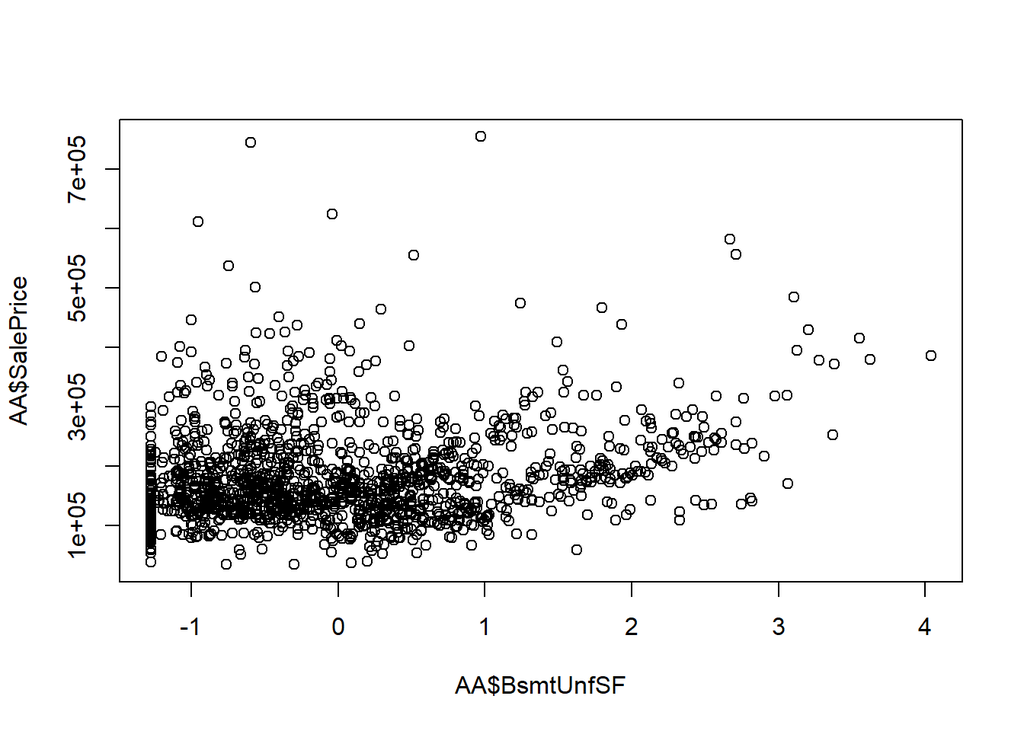

```r
plot(AA$BsmtUnfSF, AA$SalePrice)
```

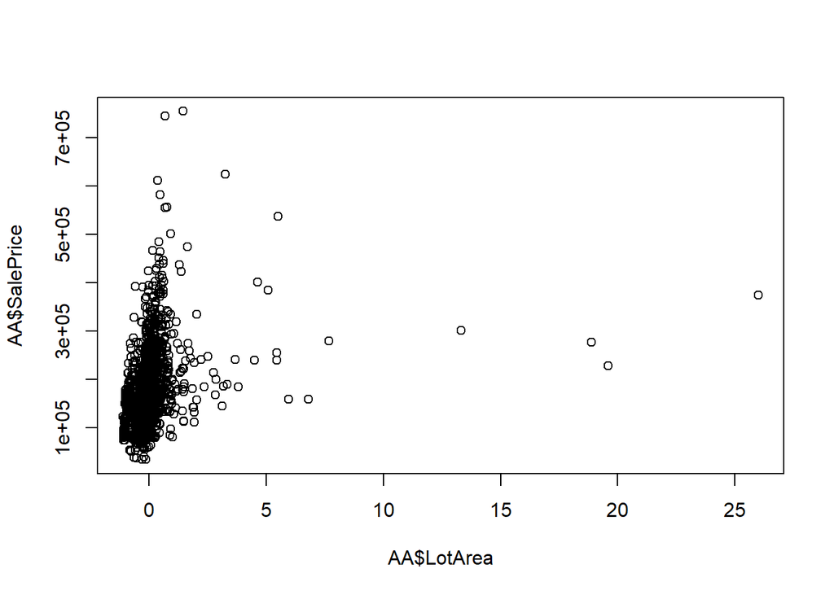

```r
plot(AA$LotArea, AA$SalePrice)
```

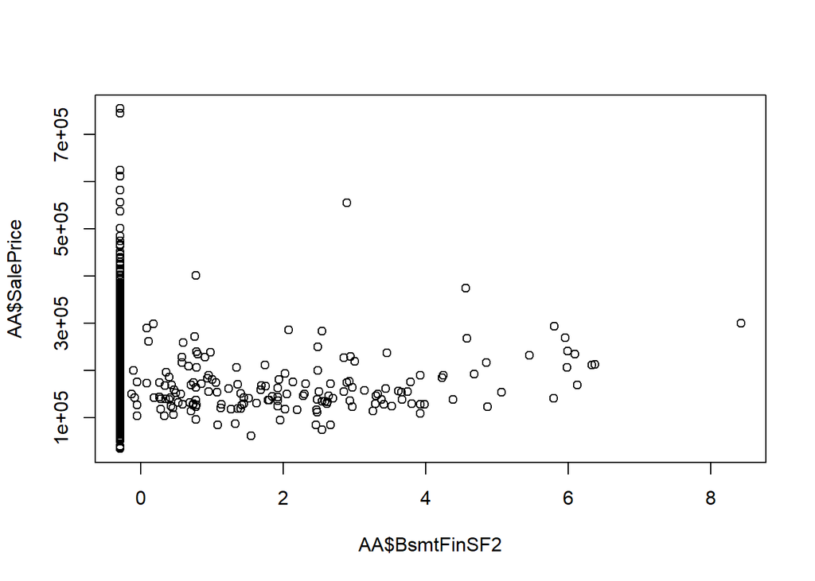

```r
plot(AA$BsmtFinSF2, AA$SalePrice)
```

The full data set is large, so there is an advantage to cutting it down in size by creating another data set comprised only of those features the regression analysis identifies as important. This simplifies the modeling task.

It is important that the training and testing sets both have similar structures, so we apply these changes to each file.

Because we identified collinearity earlier, we should not include all features related to square footage or basements. We select *GrLivArea* and *TotalBsmtSF* to represent square footage and basement features, respectively. The other features stand for themselves. This reduces the top 25 features to 16, a more manageable number.

Already, we are using analytical methods to simplify the model. This is an important development for feature selection and model execution.

```r
match(c('GrLivArea', 'TotalBsmtSF', 'RoofMatl_ClyTile',
        'YearBuilt', 'Condition2_PosN', 'OverallQual_10', 'SaleType_New',
        'Neighborhood_StoneBr', 'LotArea', 'Neighborhood_NridgHt',
        'GarageArea', 'HouseStyle_1Story', 'Neighborhood_Crawfor', 'KitchenQual_Ex',
        'Neighborhood_NoRidge', 'Fireplaces_2'), names(AmesTrain))
```

```
##  [1]  13   9 134   3  91 111 309  73   2  65  15  99  57 241  58 263
```

```r
match(c('GrLivArea', 'TotalBsmtSF', 'RoofMatl_ClyTile',
        'YearBuilt', 'Condition2_PosN', 'OverallQual_10', 'SaleType_New',
        'Neighborhood_StoneBr', 'LotArea', 'Neighborhood_NridgHt',
        'GarageArea', 'HouseStyle_1Story', 'Neighborhood_Crawfor', 'KitchenQual_Ex',
        'Neighborhood_NoRidge', 'Fireplaces_2'), names(AmesTest))
```

```
##  [1]  13   9 134   3  91 111 309  73   2  65  15  99  57 241  58 263
```

```r
AmesTrainShort <- AmesTrain[, c(13, 9, 134, 3, 91, 111, 309, 73, 2, 65, 15, 99,
                                57, 241, 58, 263)]
AmesTestShort <- AmesTest[, c(13, 9, 134, 3, 91, 111, 309, 73, 2, 65, 15, 99,
                              57, 241, 58, 263)]
```

# 5 Building the Benchmark Model

To build the model, we need to reattach the target (*SalePrice*) to the training data, then run the model on all 16 variables and check results. The model summary will identify unimportant features, which we can drop in the next round of modelling. A VIF will also identify any lingering collinearity.

```r
lm.train <- cbind(AmesTrainShort, SalePrice)
lm.test <-  AmesTestShort
lm.fit16 <- lm(SalePrice ~. , data = lm.train)
summary(lm.fit16)
```

```
##
## Call:
## lm(formula = SalePrice ~ ., data = lm.train)
##
## Residuals:
##     Min      1Q  Median      3Q     Max
## -177219  -14530     437   14665  195677
##
## Coefficients:
##                      Estimate Std. Error t value Pr(>|t|)
## (Intercept)            179713        796  225.87  < 2e-16 ***
## GrLivArea               29112       1260   23.11  < 2e-16 ***
## TotalBsmtSF             14161       1306   10.85  < 2e-16 ***
## RoofMatl_ClyTile       -12522        622  -20.13  < 2e-16 ***
## YearBuilt               18754        993   18.89  < 2e-16 ***
## Condition2_PosN        -10496        855  -12.27  < 2e-16 ***
## OverallQual_10           9983        872   11.44  < 2e-16 ***
## SaleType_New             6384        889    7.18  1.1e-12 ***
## Neighborhood_StoneBr     7075        833    8.49  < 2e-16 ***
## LotArea                  5062        687    7.37  2.8e-13 ***
## Neighborhood_NridgHt     7454        965    7.72  2.1e-14 ***
## GarageArea               9634       1059    9.09  < 2e-16 ***
## HouseStyle_1Story       -1008       1127   -0.89     0.37
## Neighborhood_Crawfor     7217        836    8.63  < 2e-16 ***
## KitchenQual_Ex          12039        971   12.40  < 2e-16 ***
## Neighborhood_NoRidge     7847        812    9.67  < 2e-16 ***
## Fireplaces_2             4104        848    4.84  1.5e-06 ***
## ---
## Signif. codes:  0 '***' 0.001 '**' 0.01 '*' 0.05 '.' 0.1 ' ' 1
##
## Residual standard error: 30300 on 1442 degrees of freedom
## Multiple R-squared:  0.856,  Adjusted R-squared:  0.854
## F-statistic:  535 on 16 and 1442 DF,  p-value: <2e-16
```

```r
vif(lm.fit16)
```

```
##            GrLivArea          TotalBsmtSF     RoofMatl_ClyTile
##                2.709                2.675                1.226
##            YearBuilt      Condition2_PosN       OverallQual_10
##                1.552                1.159                1.397
##         SaleType_New Neighborhood_StoneBr              LotArea
##                1.274                1.078                1.196
## Neighborhood_NridgHt           GarageArea    HouseStyle_1Story
##                1.374                1.751                2.010
## Neighborhood_Crawfor       KitchenQual_Ex Neighborhood_NoRidge
##                1.097                1.460                1.200
##         Fireplaces_2
##                1.192
```

The model summary indicates the *HouseStyle_1Story* feature is insignificant. Let’s remove it and run the model to see if results improve.

```r
lm.fit15 <- lm(SalePrice ~. -HouseStyle_1Story, data = lm.train)
summary(lm.fit15)
```

```
##
## Call:
## lm(formula = SalePrice ~ . - HouseStyle_1Story, data = lm.train)
##
## Residuals:
##     Min      1Q  Median      3Q     Max
## -177165  -14618     464   14465  195486
##
## Coefficients:
##                      Estimate Std. Error t value Pr(>|t|)
## (Intercept)            179715        796  225.89  < 2e-16 ***
## GrLivArea               29796       1001   29.77  < 2e-16 ***
## TotalBsmtSF             13498       1075   12.56  < 2e-16 ***
## RoofMatl_ClyTile       -12456        618  -20.16  < 2e-16 ***
## YearBuilt               18769        993   18.91  < 2e-16 ***
## Condition2_PosN        -10491        855  -12.27  < 2e-16 ***
## OverallQual_10           9968        872   11.43  < 2e-16 ***
## SaleType_New             6373        888    7.17  1.2e-12 ***
## Neighborhood_StoneBr     7048        833    8.46  < 2e-16 ***
## LotArea                  5037        686    7.34  3.5e-13 ***
## Neighborhood_NridgHt     7455        965    7.73  2.1e-14 ***
## GarageArea               9579       1058    9.06  < 2e-16 ***
## Neighborhood_Crawfor     7185        836    8.60  < 2e-16 ***
## KitchenQual_Ex          12046        971   12.41  < 2e-16 ***
## Neighborhood_NoRidge     7860        811    9.69  < 2e-16 ***
## Fireplaces_2             4109        848    4.84  1.4e-06 ***
## ---
## Signif. codes:  0 '***' 0.001 '**' 0.01 '*' 0.05 '.' 0.1 ' ' 1
##
## Residual standard error: 30300 on 1443 degrees of freedom
## Multiple R-squared:  0.856,  Adjusted R-squared:  0.854
## F-statistic:  570 on 15 and 1443 DF,  p-value: <2e-16
```

```r
vif(lm.fit15)
```

```
##            GrLivArea          TotalBsmtSF     RoofMatl_ClyTile
##                1.711                1.813                1.208
##            YearBuilt      Condition2_PosN       OverallQual_10
##                1.551                1.159                1.396
##         SaleType_New Neighborhood_StoneBr              LotArea
##                1.274                1.077                1.194
## Neighborhood_NridgHt           GarageArea Neighborhood_Crawfor
##                1.374                1.746                1.095
##       KitchenQual_Ex Neighborhood_NoRidge         Fireplaces_2
##                1.459                1.199                1.192
```

Next, we calculate the *RMSE* metric.

```r
lm.pred <- predict.lm(lm.fit15, newdata = lm.test, scale = NULL)
mean((lm.pred - lm.test)^2)
```

```
## [1] 3.746e+10
```

```r
lm.RMSE <- sqrt(mean((lm.pred - lm.test)^2))
lm.RMSE
```

```
## [1] 193543
```

The RMSE of 193,543 isn’t a strong result. This is reflected in the model’s Kaggle rating, which puts these results in the bottom third of the competition. It is interesting that the model could do well by one standard and poorly by another, but this is not unusual in statistics.

# 6 Linear Model with Interaction Terms

Some feature engineering in the form of feature interaction is worth exploring. In feature interaction, variables are combined by multiplication. A number of different combinations were tried in order to find one that might provide an *adjusted R<sup>2</sup>* comparable to the benchmark and which might further reduce the number of features in the regression model.

Interaction permits use of a much simpler model, though one with less model accuracy. The trade-off is to be expected.

```r
lm.fit.interactive <- lm(formula = SalePrice ~ GrLivArea + TotalBsmtSF + YearBuilt *
                                 Neighborhood_NridgHt +
                                 SaleType_New * Neighborhood_StoneBr * LotArea,
                                 data = AmesTrainShort)
summary(lm.fit.interactive)
```

```
##
## Call:
## lm(formula = SalePrice ~ GrLivArea + TotalBsmtSF + YearBuilt *
##     Neighborhood_NridgHt + SaleType_New * Neighborhood_StoneBr *
##     LotArea, data = AmesTrainShort)
##
## Residuals:
##     Min      1Q  Median      3Q     Max
## -211723  -17752     -75   16078  277465
##
## Coefficients:
##                                           Estimate Std. Error t value
## (Intercept)                                 148854       4890   30.44
## GrLivArea                                    40395       1089   37.10
## TotalBsmtSF                                  17400       1251   13.91
## YearBuilt                                    48008       4447   10.79
## Neighborhood_NridgHt                       -110999      19466   -5.70
## SaleType_New                                  3798       1116    3.40
## Neighborhood_StoneBr                          5897       1121    5.26
## LotArea                                       1181        862    1.37
## YearBuilt:Neighborhood_NridgHt              111062      17205    6.46
## SaleType_New:Neighborhood_StoneBr             2187        741    2.95
## SaleType_New:LotArea                        -16015       1179  -13.59
## Neighborhood_StoneBr:LotArea                  3692        857    4.31
## SaleType_New:Neighborhood_StoneBr:LotArea     3381       1382    2.45
##                                           Pr(>|t|)
## (Intercept)                                < 2e-16 ***
## GrLivArea                                  < 2e-16 ***
## TotalBsmtSF                                < 2e-16 ***
## YearBuilt                                  < 2e-16 ***
## Neighborhood_NridgHt                       1.4e-08 ***
## SaleType_New                               0.00069 ***
## Neighborhood_StoneBr                       1.7e-07 ***
## LotArea                                    0.17095
## YearBuilt:Neighborhood_NridgHt             1.5e-10 ***
## SaleType_New:Neighborhood_StoneBr          0.00323 **
## SaleType_New:LotArea                       < 2e-16 ***
## Neighborhood_StoneBr:LotArea               1.7e-05 ***
## SaleType_New:Neighborhood_StoneBr:LotArea  0.01457 *
## ---
## Signif. codes:  0 '***' 0.001 '**' 0.01 '*' 0.05 '.' 0.1 ' ' 1
##
## Residual standard error: 37100 on 1446 degrees of freedom
## Multiple R-squared:  0.784,  Adjusted R-squared:  0.782
## F-statistic:  436 on 12 and 1446 DF,  p-value: <2e-16
```

```r
lmi.pred <- predict.lm(lm.fit.interactive, newdata = lm.test, scale = NULL)
mean((lmi.pred - lm.test)^2)
```

```
## [1] 3.716e+10
```

```r
lmi.RMSE <- sqrt(mean((lm.pred - lm.test)^2))
lmi.RMSE
```

```
## [1] 193543
```

# 7 Working with Many Dimensions

The *Ames* data set has over 80 dimensions in its original form. Creating dummy variables increases dimensions to over 300. Though *Ames* is not considered a high-dimensional problem, because in *Ames* the *n* (the number of observations) is larger than *p* (the number of features), it still exhibits some challenges associated with high dimensionaltiy. In general, supervised learning problems can exhibit similar challenges, so it is helpful to mention them.

The *curse of dimensionality* describes the idea that more features do not necessarily improve goodness of fit. Using too many features, especially without adjusting for collinearity, can result in overfitting the model. An overfitted model does not scale well. It might explain a given data set well, but it cannot be applied to any other data set reliably.

Many statistical methods, such as least squares, logistic regression, and linear discriminant analysis, are not appropriate for high dimensional problems. Symptoms to watch for are a near-perfect fit and residuals approachings zero. Another symptom is variances approaching zero. During the analysis of the *Ames* data, *R* threw a number of warnings about these conditions.

Some of the features, such as those related to fireplaces, have far fewer obervations than the number of features. That is *n << p*. So certain features of *Ames* exhibits characteristics of high dimensional data.

It is important to use a number of statistical approaches to assess situations like these. Methods such as stepwise selection, ridge regression, the lasso, and principle components regression can work better in high dimensional problems.

# 8 Other Methods of Feature Selection

We can use regression methods to peform feature selection. The best subset selection approach identifies the best model given a certain number of features. In our case, we will work with the 16 features derived from the top 25 identified by the linear regression model. In best subset selection, the Residual Sum of Squares (RSS) is used to select and order features.

The table below indicates each variable’s importance to models of different sizes. For example, the *GrLivArea* is identified as the best feature to use when building a single feature model. A two-feature model would consist of *GrLivArea* and *Year Built*, and so on for more sophisticated models. A feature’s rank in importance is indicated by the first asterisk that appears in that feature’s column.

A table at the end of this document will summarize the different features and their rank using the four methods described in the study, plus boosting.

The cumulative *adjusted R<sup>2</sup>* is given in the last line of the output.

```r
regfit.full <- regsubsets(SalePrice ~ ., data = AmesTrainShort, nvmax = 16)
reg.summary <- summary(regfit.full)
reg.summary
```

```
## Subset selection object
## Call: regsubsets.formula(SalePrice ~ ., data = AmesTrainShort, nvmax = 16)
## 16 Variables  (and intercept)
##                      Forced in Forced out
## GrLivArea                FALSE      FALSE
## TotalBsmtSF              FALSE      FALSE
## RoofMatl_ClyTile         FALSE      FALSE
## YearBuilt                FALSE      FALSE
## Condition2_PosN          FALSE      FALSE
## OverallQual_10           FALSE      FALSE
## SaleType_New             FALSE      FALSE
## Neighborhood_StoneBr     FALSE      FALSE
## LotArea                  FALSE      FALSE
## Neighborhood_NridgHt     FALSE      FALSE
## GarageArea               FALSE      FALSE
```

[output cut: 92 more lines]

```r
reg.summary$adjr2
```

```
##  [1] 0.5017 0.6535 0.7131 0.7405 0.7801 0.7917 0.8046 0.8160 0.8237 0.8294
## [11] 0.8349 0.8413 0.8472 0.8519 0.8542 0.8542
```

We can create curves from this data and plot them against different model selection statistics. Here we will use four: *RSS*, *adjusted R<sup>2</sup>*, *C<sub>p</sub>*, and *BIC*. A red dot indicates the number of features with the best score for each statistic. It seems a model with 15 or 16 features, like the ones we have built, is a good approach.

```r
par(mfrow = c(2, 2))
plot(reg.summary$rss, xlab = 'Number of Variables', ylab = 'RSS', type = 'b')
which.min(reg.summary$rss)
```

```
## [1] 16
```

```r
points(16, reg.summary$rss[16], col = 'red', cex = 2, pch = 20)
plot(reg.summary$adjr2, xlab = 'Number of Variables', ylab = 'Adj R2', type = 'b')
which.max(reg.summary$adjr2)
```

```
## [1] 15
```

```r
points(15, reg.summary$adjr2[15], col = 'red', cex = 2, pch = 20)
plot(reg.summary$cp, xlab = 'Number of Variables', ylab = 'Cp', type = 'b')
which.min(reg.summary$cp)
```

```
## [1] 15
```

```r
points(15, reg.summary$cp[15], col = 'red', cex = 2, pch = 20)
plot(reg.summary$bic, xlab = 'Number of Variables', ylab = 'BIC', type = 'b')
which.min(reg.summary$bic)
```

```
## [1] 15
```

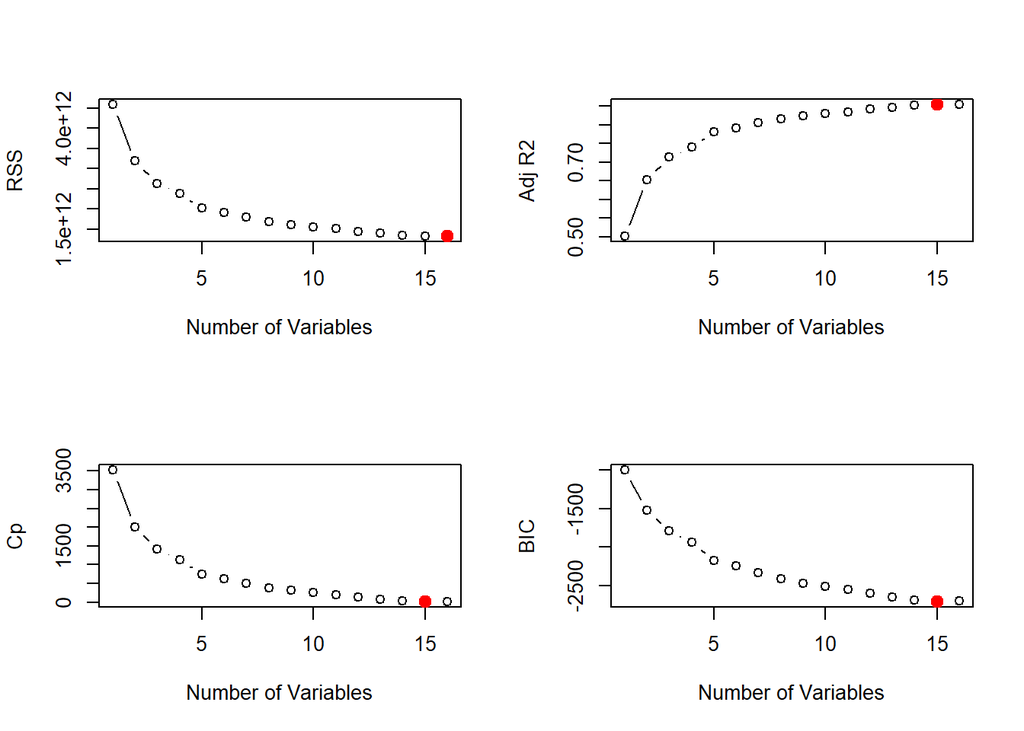

```r
points(15, reg.summary$bic[15], col = 'red', cex = 2, pch = 20)
```

Another way to convey this information is to plot the combinations of features needed to create optimal models for any given levels of metric. Following are four plots for the four model selection statistics graphed above. We can use these plots to target a particular statistic and find the particular variables associated needed to build a model yielding that statistic.

For example, if we wish to achieve an *adjusted R<sup>2</sup>* of 80.0 we would use the first seven features in the second chart. The coefficients for the seven features in that model are calculated in the last line of output.

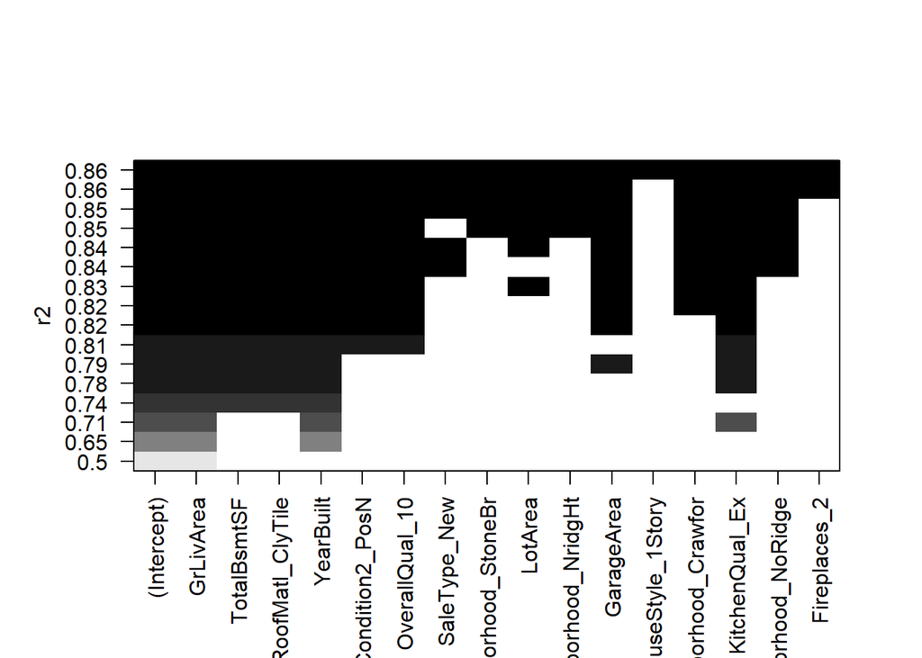

```r
plot(regfit.full, scale = 'r2')
```

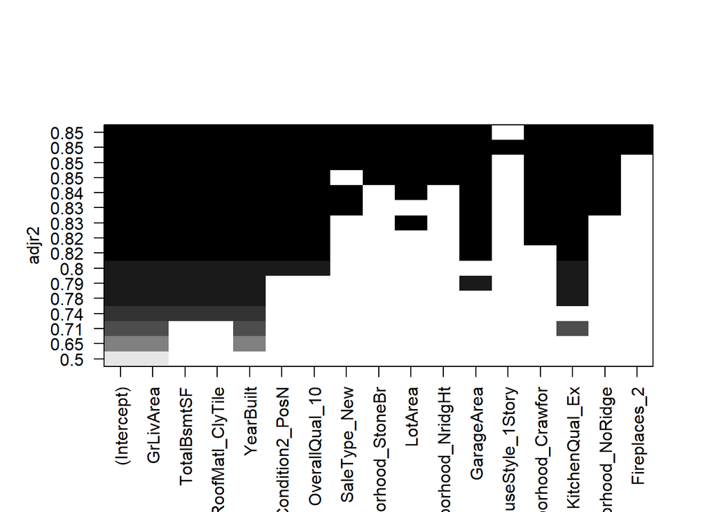

```r
plot(regfit.full, scale = 'adjr2')
```

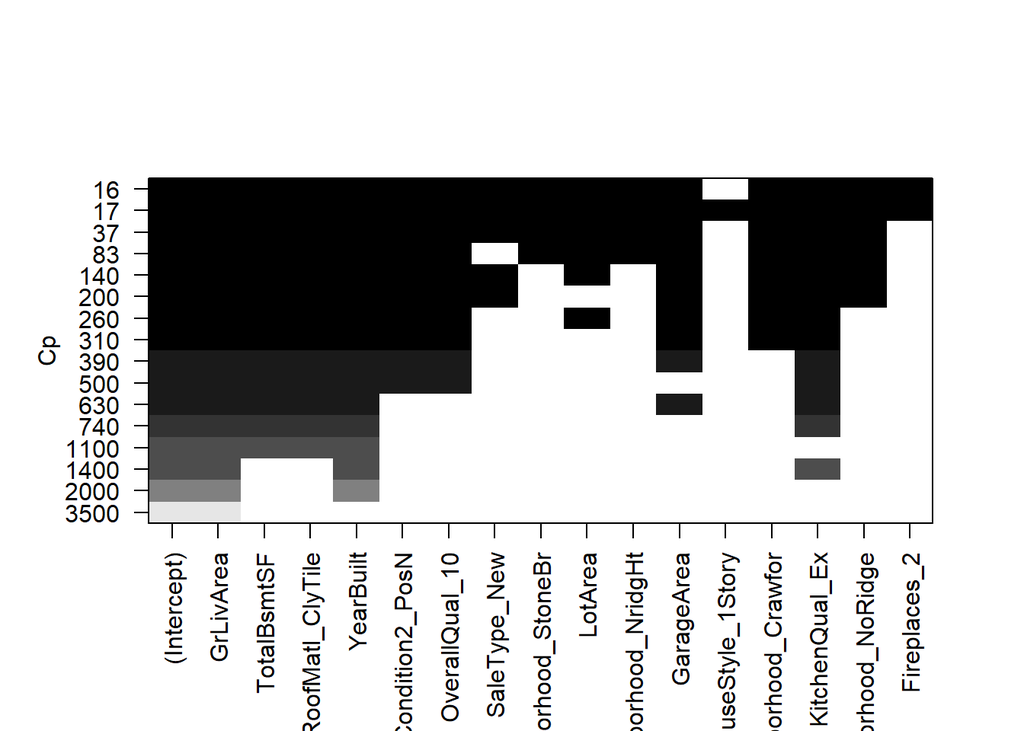

```r
plot(regfit.full, scale = 'Cp')
```

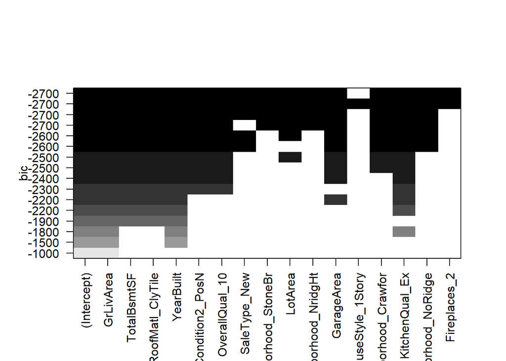

```r
plot(regfit.full, scale = 'bic')
```

```r
coef(regfit.full, 7)
```

```
##      (Intercept)        GrLivArea      TotalBsmtSF RoofMatl_ClyTile
##           179785            38251            20207           -13941
##        YearBuilt  Condition2_PosN   OverallQual_10   KitchenQual_Ex
##            22901           -10950            10686            15640
```

Finally, it is possible to accomplish feature selection using stepwise selection. In forward stepwise selection, the model starts with a single feature, then adds features one at at time. Accuracy is measured at each step and the process ends when accuracy no longer improves with each feature added. In backward stepwise selection, the process begins with all features, which are then removed one at a time. Accuracy is tracked by measuring how much it decreases with each feature removed. The process ends when no more features can be deleted without a significant loss of fit.

We will start with forward selection. As before, the table indicates the relative importance of each factor to models of different sizes.

```r
regfit.fwd <- regsubsets(SalePrice ~ ., data = AmesTrainShort, nvmax = 16,
                         method = 'forward')
summary(regfit.fwd)
```

```
## Subset selection object
## Call: regsubsets.formula(SalePrice ~ ., data = AmesTrainShort, nvmax = 16,
##     method = "forward")
## 16 Variables  (and intercept)
##                      Forced in Forced out
## GrLivArea                FALSE      FALSE
## TotalBsmtSF              FALSE      FALSE
## RoofMatl_ClyTile         FALSE      FALSE
## YearBuilt                FALSE      FALSE
## Condition2_PosN          FALSE      FALSE
## OverallQual_10           FALSE      FALSE
## SaleType_New             FALSE      FALSE
## Neighborhood_StoneBr     FALSE      FALSE
## LotArea                  FALSE      FALSE
## Neighborhood_NridgHt     FALSE      FALSE
```

[output cut: 93 more lines]

Next, we look at backward selection.

```r
regfit.bwd <- regsubsets(SalePrice ~ ., data = AmesTrainShort, nvmax = 16,
                         method = 'backward')
summary(regfit.bwd)
```

```
## Subset selection object
## Call: regsubsets.formula(SalePrice ~ ., data = AmesTrainShort, nvmax = 16,
##     method = "backward")
## 16 Variables  (and intercept)
##                      Forced in Forced out
## GrLivArea                FALSE      FALSE
## TotalBsmtSF              FALSE      FALSE
## RoofMatl_ClyTile         FALSE      FALSE
## YearBuilt                FALSE      FALSE
## Condition2_PosN          FALSE      FALSE
## OverallQual_10           FALSE      FALSE
## SaleType_New             FALSE      FALSE
## Neighborhood_StoneBr     FALSE      FALSE
## LotArea                  FALSE      FALSE
## Neighborhood_NridgHt     FALSE      FALSE
```

[output cut: 93 more lines]

Of course, these feature selection methods are limited to the 16 features selected by the regression model. That this model performed well, by the *R<sup>2</sup>* measure, gives us some confidence the features selected are a strong set. As can be seen by the charts above, the order of importance is similar for each method, though it does vary in some instances.

# 9 Feature Selection Summary Table

In this part of the study we have ued four different method to select and order the important features. The following table summarizes the results of these methods. Part 2 of this study can be [linked to here.](https://seslezak.github.io/Ames_Housing_Study/Ames_Models_Pt02.html)

| **Rank** | **Regression** | **Best Subset** | **Forward Selection** | **Backward Selection** | **Boosting** |
| --- | --- | --- | --- | --- | --- |
| **1** | GrLivArea | GrLivArea | GrLivArea | GrLivArea | GrLivArea |
| **2** | YearBuilt | YearBuilt | YearBuilt | YearBuilt | TotalBsmtSF |
| **3** | KitchenQual_Ex | KitchenQual_Ex | KitchenQual_Ex | TotalBsmtSF | YearBuilt |
| **4** | TotalBsmtSF/RoofMatl_ClyTile | TotalBsmtSF/RoofMatl_ClyTile | RoofMatl_ClyTile | RoofMatl_ClyTile | GarageArea |
| **5** | NA | NA | TotalBsmtSF | KitchenQual_Ex | LotArea |
| **6** | GarageArea | GarageArea | GarageArea | Condition2_PosN | KitchenQual_Ex |
| **7** | Condition2_PosN/OverallQual_10 | Condition2_PosN/OverallQual_10 | Condition2_PosN | OverallQual_10 | Nhood_StoneBr |
| **8** | NA | NA | OverallQual_10 | GarageArea | SaleType_New |
| **9** | Nhood_Crawfor | Nhood_Crawfor | Nhood_Crawfor | Nhood_Crawfor | Nhood_NridgHt |
| **10** | LotArea | LotArea | LotArea | Nhood_NoRidge | Nhood_Crawfor |
| **11** | SaleType_New/Nhood_NoRidge | SaleType_New/Nhood_NoRidge | Nhood_NoRidge | Nhood_StoneBr | Fireplaces_2 |
| **12** | NA | NA | SaleType_New | Nhood_NridgHt | Nhood_NoRidge |
| **13** | Nhood_StoneBr/Nhood_NridgHt | Nhood_StoneBr/Nhood_NridgHt | Nhood_StoneBr | LotArea | HouseStyle_1Story |
| **14** | NA | NA | Nhood_NridgHt | SaleType_New | NA |
| **15** | Fireplaces_2 | Fireplaces_2 | Fireplaces_2 | Fireplaces_2 | NA |
| **16** | HouseStyle_1Story | HouseStyle_1Story | HouseStyle_1Story | HouseStyle_1Story | NA |